# Predictive distribution study analyses

### Coefficients of mean log(KLD)

First we’ll derive the coefficients for mu (the mean of log(KLD)).

We’ll extract samples of the coefficients from the model and display them as raindrop plots, using the same display order as for the recall task:

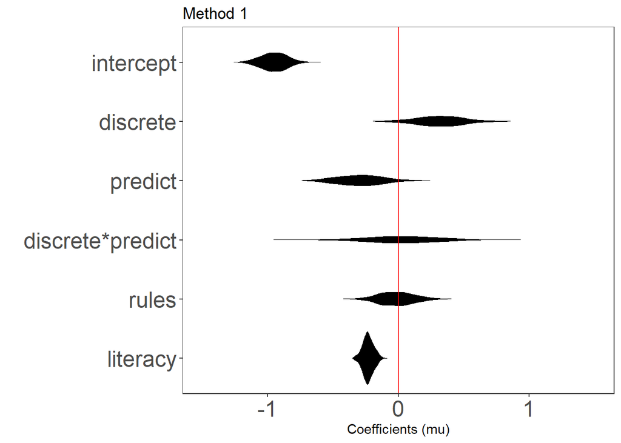

```r
plot_kld_model_mu_coefs(m_transfer_disc) + xlim(-1.5, 1.5) + ggtitle("Method 1")
```

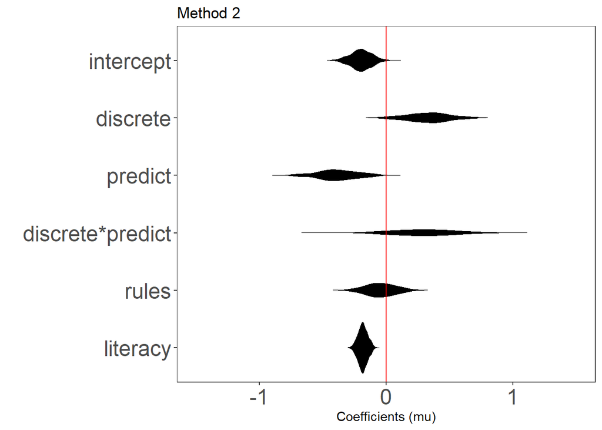

```r
plot_kld_model_mu_coefs(m_transfer_disc_zeros) + xlim(-1.5, 1.5) + ggtitle("Method 2")
```

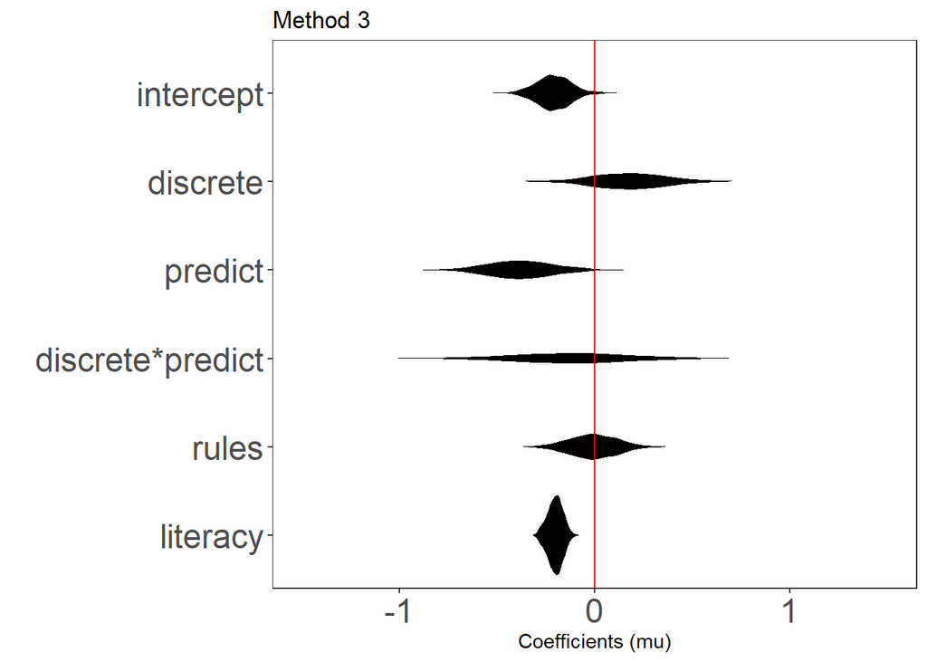

```r
plot_kld_model_mu_coefs(m_transfer_cont_zeros) + xlim(-1.5, 1.5) + ggtitle("Method 3")
```

### Coefficients of log(sd) of log(kld)

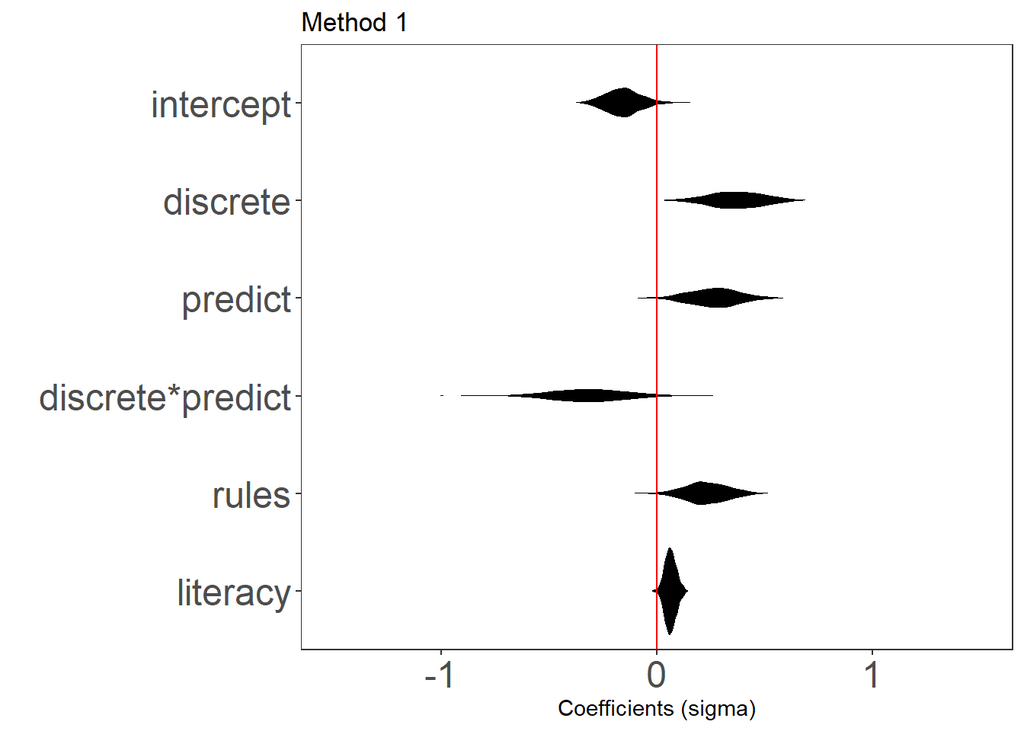

```r
plot_kld_model_sigma_coefs(m_transfer_disc) + xlim(-1.5, 1.5) + ggtitle("Method 1")
```

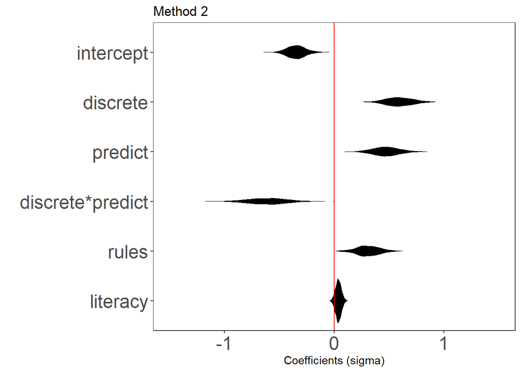

```r
plot_kld_model_sigma_coefs(m_transfer_disc_zeros) + xlim(-1.5, 1.5) + ggtitle("Method 2")
```

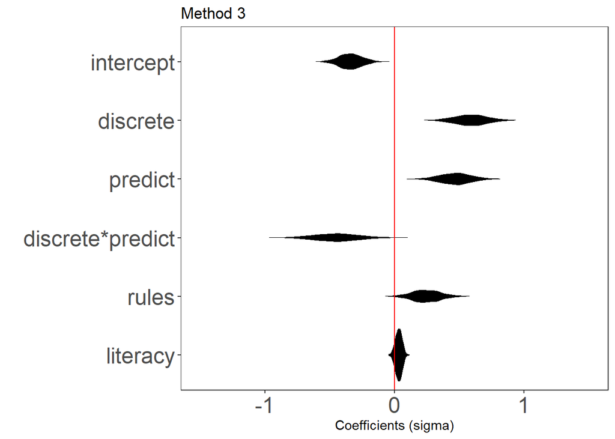

```r
plot_kld_model_sigma_coefs(m_transfer_cont_zeros) + xlim(-1.5, 1.5) + ggtitle("Method 3")
```

### Expected values of mean and sd by condition

The previous plots show the estimates of the coefficients, which mostly gives us differences from the baseline condition (continuous + no predict), and in the case of `discrete*predict`, gives us difference from continuous + predict.

As in the recall task, we will also look at the estimated mean (or sd) on a per-condition basis (so-called marginal estimates).

#### Expected mu by condition

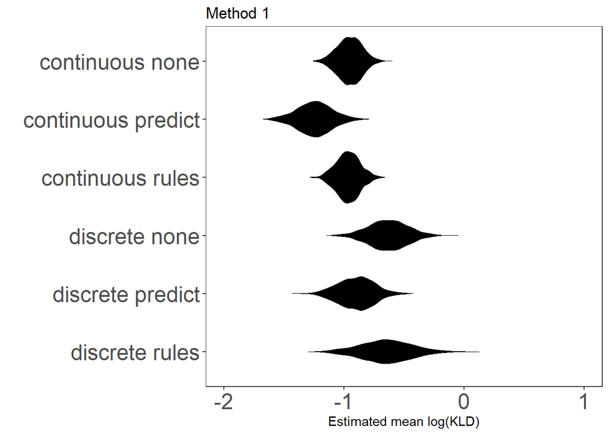

```r
plot_kld_model_expected_mu(m_transfer_disc) + xlim(-2, 1) + ggtitle("Method 1")
```

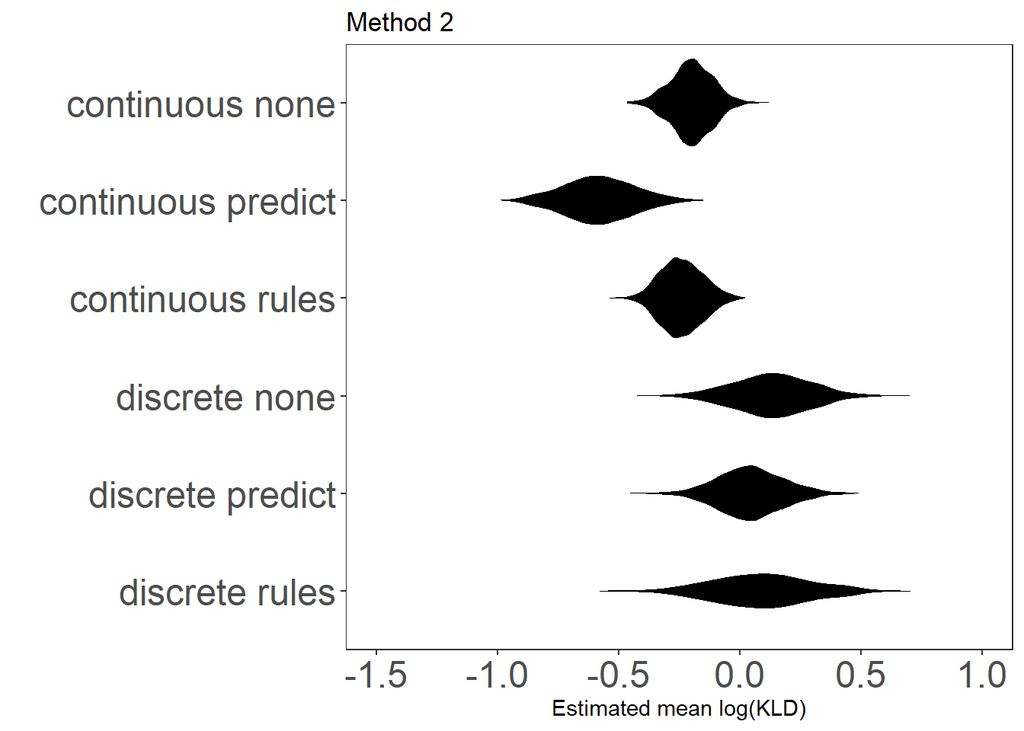

```r
plot_kld_model_expected_mu(m_transfer_disc_zeros) + xlim(-1.5, 1) + ggtitle("Method 2")
```

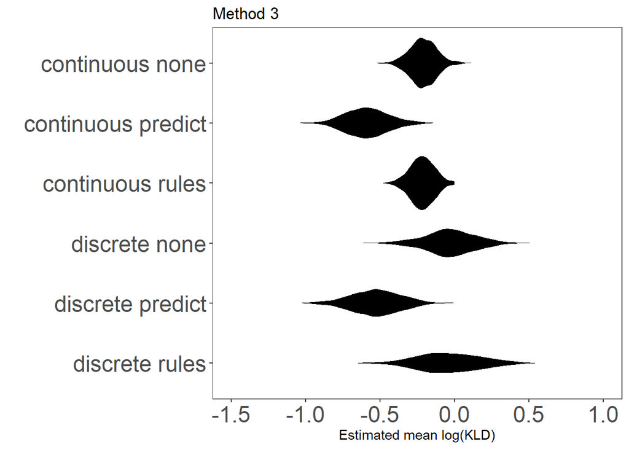

```r
plot_kld_model_expected_mu(m_transfer_cont_zeros) + xlim(-1.5, 1) + ggtitle("Method 3")
```

#### Expected log(sd) by condition

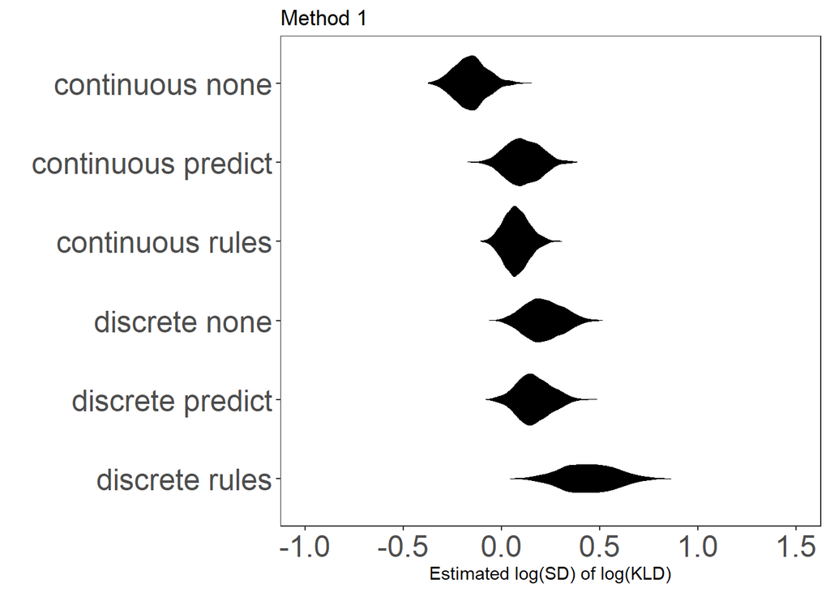

```r
plot_kld_model_expected_sigma(m_transfer_disc) + xlim(-1, 1.5) + ggtitle("Method 1")
```

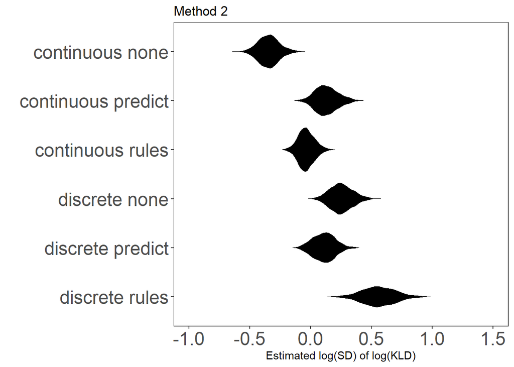

```r
plot_kld_model_expected_sigma(m_transfer_disc_zeros) + xlim(-1, 1.5) + ggtitle("Method 2")
```

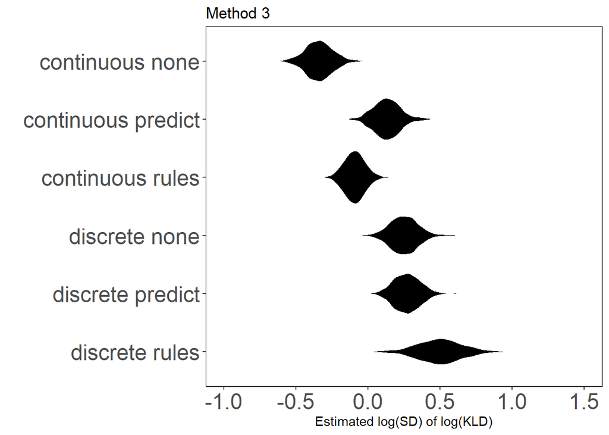

```r
plot_kld_model_expected_sigma(m_transfer_cont_zeros) + xlim(-1, 1.5) + ggtitle("Method 3")
```

```r
#for comparing population sampling dist and observed sampling dist to see if some participants are confused by the difference
adfp_gamlssp = adfp %>%
  dplyr::select(discrete, predict, rules, prescore, true_sampling_kl) #gamlss needs all columns without NAs
mg = gamlss(log(true_sampling_kl) ~ discrete*predict + rules+prescore,
  sigma.formula = ~ discrete*predict + rules+prescore,
  data=adfp_gamlssp)
```

```
## GAMLSS-RS iteration 1: Global Deviance = 998.7449
## GAMLSS-RS iteration 2: Global Deviance = 998.5183
## GAMLSS-RS iteration 3: Global Deviance = 998.5177
```

```r
summary(mg)
```

```
## Family:  c("NO", "Normal")
##
## Call:  gamlss(formula = log(true_sampling_kl) ~ discrete *
##     predict + rules + prescore, sigma.formula = ~discrete *
##     predict + rules + prescore, data = adfp_gamlssp)
##
## Fitting method: RS()
##
## ------------------------------------------------------------------
## Mu link function:  identity
## Mu Coefficients:
##                  Estimate Std. Error t value Pr(>|t|)
## (Intercept)      -0.03839    0.11688  -0.328   0.7428
## discrete          0.08797    0.17254   0.510   0.6105
## predict          -0.44000    0.17659  -2.492   0.0132 *
## rules             0.02257    0.12752   0.177   0.8596
## prescore         -0.20526    0.03679  -5.579 4.88e-08 ***
## discrete:predict -0.08040    0.27336  -0.294   0.7688
## ---
## Signif. codes:  0 '***' 0.001 '**' 0.01 '*' 0.05 '.' 0.1 ' ' 1
##
## ------------------------------------------------------------------
## Sigma link function:  log
## Sigma Coefficients:
##                  Estimate Std. Error t value Pr(>|t|)
## (Intercept)      -0.29659    0.10073  -2.944  0.00345 **
## discrete          0.29867    0.12893   2.316  0.02111 *
## predict           0.33833    0.12836   2.636  0.00877 **
## rules             0.06602    0.11258   0.586  0.55797
## prescore          0.03549    0.02785   1.274  0.20336
## discrete:predict -0.23131    0.18273  -1.266  0.20643
## ---
## Signif. codes:  0 '***' 0.001 '**' 0.01 '*' 0.05 '.' 0.1 ' ' 1
##
## ------------------------------------------------------------------
## No. of observations in the fit:  360
## Degrees of Freedom for the fit:  12
##       Residual Deg. of Freedom:  348
##                       at cycle:  3
##
## Global Deviance:     998.5177
##             AIC:     1022.518
##             SBC:     1069.151
```

# Analyze responses to text probability questions

# What is overall error like? What about for specific questions?

```r
#Overall
ddply(adsL,~tasktype,summarise,mean=mean(erra, na.rm=TRUE),sd=sd(erra, na.rm=TRUE))
```

```
##   tasktype     mean       sd
## 1     c_np 25.95117 26.08948
## 2      c_p 21.14269 25.35697
## 3     d_np 22.31780 27.87256
## 4      d_p 12.53327 20.97480
## 5    rc_np 22.47987 27.51165
## 6    rd_np 19.81356 24.95091
```

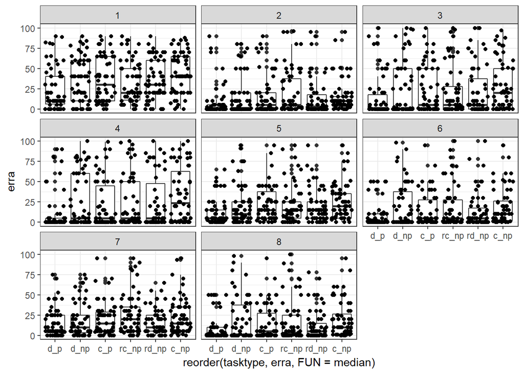

```r
ggplot(adsL, aes(x=reorder(tasktype, erra, FUN=median), erra)) + geom_boxplot() + geom_jitter() + facet_wrap( ~ q_num) #useless chart
```

```r
#Linear mixed effects model -- first in lme4
full.model <- lmer(erra  ~ discrete + predict + prescore + discrete*predict + rules + (1+prescore| workerId) + (1+prescore| q_num), data=adsL)
summary(full.model)
```

```
## Linear mixed model fit by REML ['lmerMod']
## Formula:
## erra ~ discrete + predict + prescore + discrete * predict + rules +
##     (1 + prescore | workerId) + (1 + prescore | q_num)
##    Data: adsL
##
## REML criterion at convergence: 26108.7
##
## Scaled residuals:
##     Min      1Q  Median      3Q     Max
## -2.7514 -0.5149 -0.1452  0.2580  4.5316
##
## Random effects:
##  Groups   Name        Variance Std.Dev. Corr
##  workerId (Intercept) 250.661  15.832
##           prescore     12.999   3.605   -0.62
##  q_num    (Intercept)  60.068   7.750
##           prescore      1.796   1.340   -0.59
##  Residual             395.085  19.877
## Number of obs: 2896, groups:  workerId, 361; q_num, 8
##
## Fixed effects:
##                  Estimate Std. Error t value
## (Intercept)       32.8421     3.5503   9.250
## discrete          -3.0302     2.7586  -1.098
## predict           -4.3483     2.7705  -1.570
## prescore          -3.9959     0.7661  -5.216
## rules             -4.2440     2.3868  -1.778
## discrete:predict  -4.5700     3.9025  -1.171
##
## Correlation of Fixed Effects:
##             (Intr) discrt predct prescr rules
## discrete    -0.375
## predict     -0.365  0.487
## prescore    -0.541 -0.011 -0.032
## rules       -0.424  0.565  0.564 -0.034
## dscrt:prdct  0.267 -0.707 -0.709  0.004 -0.399
```

```r
coefs <- data.frame(coef(summary(full.model)))
# use normal distribution to approximate p-value
coefs$p.z <- 2 * (1 - pnorm(abs(coefs$t.value)))
coefs
```

```
##                   Estimate Std..Error   t.value          p.z
## (Intercept)      32.842083  3.5503457  9.250390 0.000000e+00
## discrete         -3.030155  2.7586452 -1.098421 2.720205e-01
## predict          -4.348322  2.7704732 -1.569523 1.165261e-01
## prescore         -3.995861  0.7660975 -5.215864 1.829623e-07
## rules            -4.243978  2.3868249 -1.778085 7.538989e-02
## discrete:predict -4.569971  3.9024643 -1.171047 2.415797e-01
```

# Now in stan (via brms)

```r
myvars <- c("q_num", "workerId", "erra", "discrete", "predict", "rules", "prescore")
adsL_stan <- adsL[myvars]

m1_g2s <- brm(erra ~ discrete + predict + discrete*predict + rules + prescore + (1 | workerId) + (1 | q_num), data = adsL_stan)
m1_g2s
```

```
##  Family: gaussian(identity)
## Formula: erra ~ discrete + predict + discrete * predict + rules + prescore + (1 | workerId) + (1 | q_num)
##    Data: adsL_stan (Number of observations: 2896)
## Samples: 4 chains, each with iter = 2000; warmup = 1000; thin = 1;
##          total post-warmup samples = 4000
##     ICs: LOO = Not computed; WAIC = Not computed
##
## Group-Level Effects:
## ~q_num (Number of levels: 8)
##               Estimate Est.Error l-95% CI u-95% CI Eff.Sample Rhat
## sd(Intercept)     7.94      2.73      4.5    14.55       1272 1.01
##
## ~workerId (Number of levels: 361)
##               Estimate Est.Error l-95% CI u-95% CI Eff.Sample Rhat
## sd(Intercept)    13.65      0.64    12.44    14.94       1473    1
##
## Population-Level Effects:
##                  Estimate Est.Error l-95% CI u-95% CI Eff.Sample Rhat
## Intercept           33.29      3.58    26.19    40.41        935 1.00
## discrete            -3.04      2.80    -8.46     2.49       1020 1.01
## predict             -3.95      2.81    -9.37     1.66        970 1.01
## rules               -3.87      2.36    -8.44     0.77        943 1.01
## prescore            -4.22      0.57    -5.34    -3.12       1105 1.00
## discrete:predict    -5.28      3.90   -12.99     2.33        918 1.01
##
## Family Specific Parameters:
##       Estimate Est.Error l-95% CI u-95% CI Eff.Sample Rhat
## sigma    19.97      0.28    19.42    20.53       4000    1
##
## Samples were drawn using sampling(NUTS). For each parameter, Eff.Sample
## is a crude measure of effective sample size, and Rhat is the potential
## scale reduction factor on split chains (at convergence, Rhat = 1).
```

Plotting the coefficients with 80 and 95% intervals. Note: Some readers may experience an error in generating the plot due to a known bug with plotting rstan model fits when using using some versions of ggplot2. (https://github.com/tidyverse/ggplot2/blob/master/revdep/problems.md)

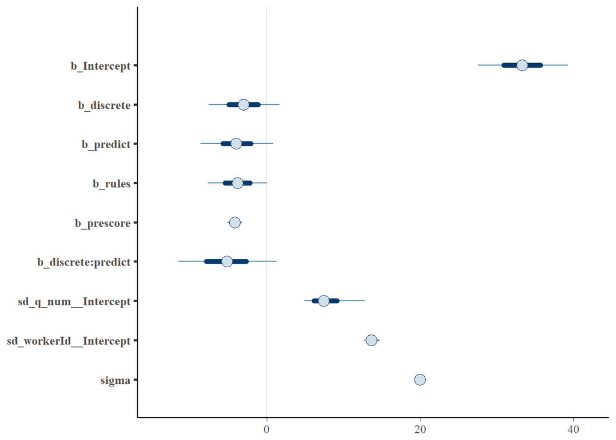

```r
stanplot(m1_g2s)
```

```r
#posterior distributions for coefficients
coef_continuous = posterior_samples(m1_g2s) %$% {b_Intercept}
coef_discrete = posterior_samples(m1_g2s) %$% {b_discrete}
coef_predict = posterior_samples(m1_g2s) %$% {b_predict}
coef_discrete_predict = posterior_samples(m1_g2s) %$% {`b_discrete:predict`}
coef_rules = posterior_samples(m1_g2s) %$% {b_rules}
coef_prescore = posterior_samples(m1_g2s) %$% {b_prescore}

violin <- data.frame(cbind(coef_continuous,coef_predict,coef_discrete,coef_discrete_predict,coef_rules,coef_prescore))
violin <- reshape(varying = c("coef_continuous","coef_predict","coef_discrete","coef_discrete_predict","coef_rules","coef_prescore"), v.names = "estimate",  timevar="condition", times=c("coef_continuous","coef_predict","coef_discrete","coef_discrete_predict","coef_rules","coef_prescore"), direction = "long", data=violin)
violin$condition <- ifelse(violin$condition=="coef_continuous", "intercept", ifelse(violin$condition=="coef_rules", "rules", ifelse(violin$condition=="coef_predict", "predict", ifelse(violin$condition=="coef_discrete_predict", "discrete*predict", ifelse(violin$condition=="coef_discrete", "discrete", "prescore")))))
```

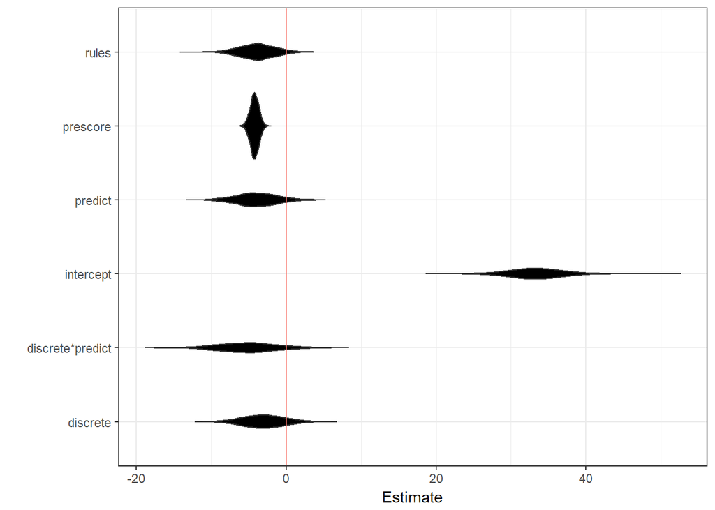

```r
ggplot() + geom_violin(data=violin, mapping=aes(x=condition, estimate),fill="black") + coord_flip() + geom_hline(aes(yintercept=0, colour="red"))+ guides(color=FALSE) + labs(y="Estimate", x="")
```

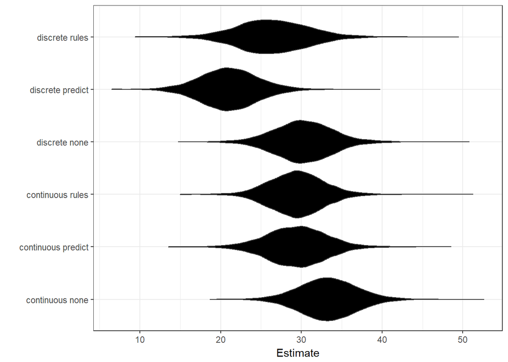

```r
#posterior distributions for conditions
beta_continuous_posterior = posterior_samples(m1_g2s) %$% {b_Intercept}
beta_discrete_posterior = posterior_samples(m1_g2s) %$% {b_Intercept + b_discrete}
beta_predict_posterior = posterior_samples(m1_g2s) %$% {b_Intercept + b_predict}
beta_discrete_predict_posterior = posterior_samples(m1_g2s) %$% {b_Intercept + b_discrete + b_predict + `b_discrete:predict`}
beta_rules_posterior = posterior_samples(m1_g2s) %$% {b_Intercept + b_rules}
beta_discrete_rules_posterior = posterior_samples(m1_g2s) %$% {b_Intercept + b_rules + b_discrete}

violin <- data.frame(cbind(beta_continuous_posterior,beta_predict_posterior,beta_discrete_posterior,beta_discrete_predict_posterior,beta_rules_posterior,beta_discrete_rules_posterior))
violin <- reshape(varying = c("beta_continuous_posterior","beta_predict_posterior","beta_discrete_posterior","beta_discrete_predict_posterior","beta_rules_posterior","beta_discrete_rules_posterior"), v.names = "estimate",  timevar="condition", times=c("beta_continuous_posterior","beta_predict_posterior","beta_discrete_posterior","beta_discrete_predict_posterior","beta_rules_posterior","beta_discrete_rules_posterior"), direction = "long", data=violin)
violin$condition <- ifelse(violin$condition=="beta_continuous_posterior", "continuous none", ifelse(violin$condition=="beta_rules_posterior", "continuous rules", ifelse(violin$condition=="beta_predict_posterior", "continuous predict", ifelse(violin$condition=="beta_discrete_predict_posterior", "discrete predict", ifelse(violin$condition=="beta_discrete_rules_posterior", "discrete rules", "discrete none")))))

ggplot() + geom_violin(data=violin, mapping=aes(x=condition, estimate),fill="black") + coord_flip() + guides(color=FALSE) + labs(y="Estimate", x="")
```